# 9. Statistical Inference practices

3316712 AI Computational Pharmaceutical Sciences

Natapol Pornputtapong, PhD

Chulalongkorn University

02 Apr 2026

# Statistical testing

## Statistics <sup>1</sup>

discipline that concerns the collection, organization, analysis, interpretation and presentation of data

[^1]: Wikipedia; Romijn, Jan-Willem (2014). “Philosophy of statistics”. Stanford Encyclopedia of Philosophy.

## Statistic tools Family

```
graph TD
  A[Statistics] --> B[Descriptive]
  A --> C[Inferential]
  A --> D[Bayesian]
  A --> E[Statistical learning]

  B --> F[Central tendency]
  B --> G[Distribution]
  B --> H[Plot]

  C --> I[T-test]
  C --> J[ANOVA]

  E --> K[AI]
  E --> L[NN]
```

## Drug testing

- 2 new pain killer, test in 10 persons that have pain.
  - A: 8 of 10 get better.
  - B: 9 of 10 get better.
- 2 new pain killer, test in 100 persons that have pain.
  - A: 70 of 100 get better.
  - B: 79 of 100 get better.

## Statistical inference

Observe  
**Sample**

**——>**

Infer  
**Population**

## Hypothesis testing: statistical inference

1. Convert the **research hypothesis to null hypothesis** and try to disprove. The decide which test & tails to be used.
2. decide on a **significance level** – the probability with which we are prepared to make a wrong decision if the null hypothesis is true.
3. Experimental design & do data collection
4. Perform **requirement check** then **Calculate p-value**
5. **Compare p-value** with a significance level then end up either accepting or rejecting the null hypothesis.
6. Interpretation

## State the hypothesis

- Parameters
  - mean $(\mu)$
  - standard variation $(\sigma)$
  - distribution
- Alternative relationship
  - not equal $(\neq)$ - two tail
  - greater than $(\gt)$ - one tail
  - lower than $(\lt)$ - one tail

## Hypotheses

| Null (not-sig: true) | Alternative (sig: true) |
| --- | --- |
| $\mu = 15$ | $\mu \neq 15$ |
| $\mu \leq 15$ | $\mu \gt 15$ |
| $\mu_1 = \mu_2$ | $\mu_1 \neq \mu_2$ |
| $\mu_1 \geq \mu_2$ | $\mu_1 \lt \mu_2$ |
| $\mu_1 = \mu_2 = \mu_3 ...$ | $\mu_1 \neq \mu_2, \mu_1 \neq \mu_3 ...$ |

## Choose the test: Parametric and non-parametric

**Parametric**

- test based on parameterized distributions
  - T-Test
  - ANOVA
- More strictness
- Requirement check

**Non parametric**

- not based on parameterized distributions
  - Mann-Whitney
  - Kruskal-Wallis
- Less strictness
- No requirement

## Decide the significant level

|  | null hypothesis is true | null hypothesis is false |
| --- | --- | --- |
| accept null hypothesis | Good | Type II ($\beta$) error |
| reject null hypothesis | Type I ($\alpha$) error | Good |

## Choosing the test

1. Choosing the test based on the hypothesis
2. Decide on the significant level & collect the data
3. Choose the parametric first
4. Checking the assumption of the test
5. Calculate p-value, confidence limit
6. Accept or reject null hypothesis

## P-Value

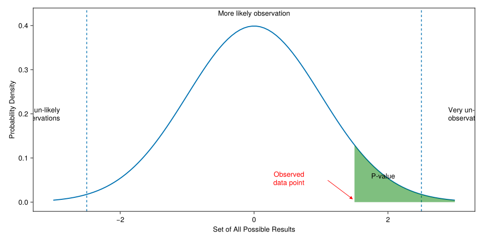

## Wrong interpretation of P-Value

When the same hypothesis is tested in different studies; if P of Drug ‘A’ is smaller than drug ‘B’, then drug ‘A’ is more effective than drug ‘b’.

## choosing Statistic Testing

- **type of parameter**: mean, variance, distribution, proportion
- **number of sample group**: one, two, more
- **type of variable**: focus on continuous
- **number of independent variable**: focus on one
- **number of dependent variable**: focus on one
- **parametric vs non parametric**

## Testing of Mean 1 sample

[output not shown]

## Testing of Mean 2 samples

| normal ? | extra requirement | test to use |
| --- | --- | --- |
| yes | sample pair | paired T-Test of mean |
| no | sample pair | Wilcoxon signed rank test |
| yes | equal variance | two sample T-Test of mean of equal variance |
| yes | nonequal variance | two sample T-Test of mean of non equal variance |
| no | N/A | Wilcoxon rank-sum test |

## Testing of Mean more samples

| normal ? | extra requirement | test to use |
| --- | --- | --- |
| yes | N/A | One-Way ANOVA |
| no | N/A | Kruskal-Wallis test |

## Testing of Distribution

- Shapiro-Wilk test of normality

## library installation

```julia
using Pkg
Pkg.add(["Tidier", "TidierFiles", "TidierPlots", "HypothesisTests", "GLM", "CairoMakie", "Distributions", "AnovaGLM"])
```

## calling library

```julia
using Tidier, TidierFiles, TidierPlots, HypothesisTests, GLM, CairoMakie, Distributions, AnovaGLM
```

## The NHANES data

| Variable | Definition |
| --- | --- |
| id | A unique sample identifier |
| Gender | Gender (sex) of study participant coded as male or female |
| Age | Age in years at screening of study participant. Note: Subjects 80 years or older were recorded as 80. |
| Race | Reported race of study participant, including non-Hispanic Asian category: Mexican, Hispanic, White, Black, Asian, or Other. Not availale for 2009-10. |
| Education | Educational level of study participant Reported for participants aged 20 years or older. One of 8thGrade, 9-11thGrade, HighSchool, SomeCollege, or CollegeGrad. |
| MaritalStatus | Marital status of study participant. Reported for participants aged 20 years or older. One of Married, Widowed, Divorced, Separated, NeverMarried, or LivePartner (living with partner). |
| RelationshipStatus | Simplification of MaritalStatus, coded as Committed if MaritalStatus is Married or LivePartner, and Single otherwise. |
| Insured | Indicates whether the individual is covered by health insurance. |
| Income | Numerical version of HHIncome derived from the middle income in each category |
| Poverty | A ratio of family income to poverty guidelines. Smaller numbers indicate more poverty |
| HomeRooms | How many rooms are in home of study participant (counting kitchen but not bathroom). 13 rooms = 13 or more rooms. |
| HomeOwn | One of Home, Rent, or Other indicating whether the home of study participant or someone in their family is owned, rented or occupied by some other arrangement. |
| Work | Indicates whether the individual is current working or not. |
| Weight | Weight in kg |
| Height | Standing height in cm. Reported for participants aged 2 years or older. |
| BMI | Body mass index (weight/height2 in kg/m2). Reported for participants aged 2 years or older. |
| Pulse | 60 second pulse rate |
| BPSys | Combined systolic blood pressure reading, following the procedure outlined for BPXSAR. |
| BPDia | Combined diastolic blood pressure reading, following the procedure outlined for BPXDAR. |
| Testosterone | Testerone total (ng/dL). Reported for participants aged 6 years or older. Not available for 2009-2010. |
| HDLChol | Direct HDL cholesterol in mmol/L. Reported for participants aged 6 years or older. |
| TotChol | Total HDL cholesterol in mmol/L. Reported for participants aged 6 years or older. |
| Diabetes | Study participant told by a doctor or health professional that they have diabetes. Reported for participants aged 1 year or older as Yes or No. |
| DiabetesAge | Age of study participant when first told they had diabetes. Reported for participants aged 1 year or older. |
| nPregnancies | How many times participant has been pregnant. Reported for female participants aged 20 years or older. |
| nBabies | How many of participants deliveries resulted in live births. Reported for female participants aged 20 years or older. |
| SleepHrsNight | Self-reported number of hours study participant usually gets at night on weekdays or workdays. Reported for participants aged 16 years and older. |
| PhysActive | Participant does moderate or vigorous-intensity sports, fitness or recreational activities (Yes or No). Reported for participants 12 years or older. |
| PhysActiveDays | Number of days in a typical week that participant does moderate or vigorous-intensity activity. Reported for participants 12 years or older. |
| AlcoholDay | Average number of drinks consumed on days that participant drank alcoholic beverages. Reported for participants aged 18 years or older. |
| AlcoholYear | Estimated number of days over the past year that participant drank alcoholic beverages. Reported for participants aged 18 years or older. |
| SmokingStatus | Smoking status: Current Former or Never. |

## import data to dataframe

```julia
nh = read_csv("nhanes.csv", missingstring="NA")
nh
```

5000×32 DataFrame

4975 rows omitted

| Row | id Int64 | Gender String7 | Age Int64 | Race String15 | Education String15? | MaritalStatus String15? | RelationshipStatus String15? | Insured String3? | Income Int64? | Poverty Float64? | HomeRooms Int64? | HomeOwn String7? | Work String15? | Weight Float64? | Height Float64? | BMI Float64? | Pulse Int64? | BPSys Int64? | BPDia Int64? | Testosterone Float64? | HDLChol Float64? | TotChol Float64? | Diabetes String3? | DiabetesAge Int64? | nPregnancies Int64? | nBabies Int64? | SleepHrsNight Int64? | PhysActive String3? | PhysActiveDays Int64? | … |
| --- | --- | --- | --- | --- | --- | --- | --- | --- | --- | --- | --- | --- | --- | --- | --- | --- | --- | --- | --- | --- | --- | --- | --- | --- | --- | --- | --- | --- | --- | --- |
| 1 | 62163 | male | 14 | Asian | missing | missing | missing | Yes | 100000 | 4.07 | 6 | Rent | missing | 49.4 | 168.9 | 17.3 | 72 | 107 | 37 | 274.95 | 1.14 | 3.98 | No | missing | missing | missing | missing | No | 1 | … |
| 2 | 62172 | female | 43 | Black | High School | NeverMarried | Single | Yes | 22500 | 2.02 | 4 | Rent | NotWorking | 98.6 | 172.0 | 33.3 | 80 | 103 | 72 | 47.53 | 1.89 | 4.37 | No | missing | 3 | 2 | 8 | No | 2 | … |
| 3 | 62174 | male | 80 | White | College Grad | Married | Committed | Yes | 70000 | 4.3 | 7 | Own | NotWorking | 95.8 | 168.1 | 33.9 | 56 | 97 | 39 | 642.82 | 1.4 | 5.25 | No | missing | missing | missing | 9 | No | 7 | … |
| 4 | 62174 | male | 80 | White | College Grad | Married | Committed | Yes | 70000 | 4.3 | 7 | Own | NotWorking | 95.8 | 168.1 | 33.9 | 56 | 97 | 39 | 642.82 | 1.4 | 5.25 | No | missing | missing | missing | 9 | No | 5 | … |
| 5 | 62175 | male | 5 | White | missing | missing | missing | Yes | 12500 | 0.39 | 7 | Rent | missing | 23.9 | 119.8 | 16.7 | missing | missing | missing | missing | missing | missing | No | missing | missing | missing | missing | missing | 7 | … |
| 6 | 62176 | female | 34 | White | College Grad | Married | Committed | Yes | 100000 | 5.0 | 8 | Own | NotWorking | 68.7 | 171.6 | 23.3 | 92 | 107 | 69 | 21.11 | 1.42 | 4.42 | No | missing | 5 | 2 | 7 | Yes | 5 | … |
| 7 | 62178 | male | 80 | White | High School | Widowed | Single | Yes | 2500 | 0.05 | 6 | Own | NotWorking | 85.9 | 173.5 | 28.5 | 68 | 121 | 72 | 562.78 | 1.22 | 5.2 | No | missing | missing | missing | 6 | No | missing | … |
| 8 | 62180 | male | 35 | White | College Grad | Married | Committed | Yes | 22500 | 0.87 | 6 | Own | Working | 89.0 | 178.7 | 27.9 | 66 | 107 | 66 | 401.78 | 0.85 | 3.7 | No | missing | missing | missing | 7 | No | missing | … |
| 9 | 62186 | female | 17 | Black | missing | missing | missing | Yes | 22500 | 0.53 | 6 | Own | NotWorking | 63.5 | 166.4 | 22.9 | 86 | 108 | 64 | 27.0 | 1.4 | 3.21 | No | missing | missing | missing | 7 | Yes | 4 | … |
| 10 | 62190 | female | 15 | Mexican | missing | missing | missing | Yes | 30000 | 0.54 | 4 | Rent | missing | 38.5 | 150.5 | 17.0 | 76 | 113 | 27 | 22.2 | 1.63 | 4.11 | No | missing | missing | missing | missing | No | 7 | … |
| 11 | 62199 | male | 57 | White | College Grad | LivePartner | Committed | Yes | 100000 | 5.0 | 4 | Rent | Working | 96.9 | 186.0 | 28.0 | 84 | 110 | 65 | 269.24 | 0.91 | 4.42 | No | missing | missing | missing | 8 | Yes | 2 | … |
| 12 | 62199 | male | 57 | White | College Grad | LivePartner | Committed | Yes | 100000 | 5.0 | 4 | Rent | Working | 96.9 | 186.0 | 28.0 | 84 | 110 | 65 | 269.24 | 0.91 | 4.42 | No | missing | missing | missing | 8 | Yes | missing | … |
| 13 | 62199 | male | 57 | White | College Grad | LivePartner | Committed | Yes | 100000 | 5.0 | 4 | Rent | Working | 96.9 | 186.0 | 28.0 | 84 | 110 | 65 | 269.24 | 0.91 | 4.42 | No | missing | missing | missing | 8 | Yes | 7 | … |
| ⋮ | ⋮ | ⋮ | ⋮ | ⋮ | ⋮ | ⋮ | ⋮ | ⋮ | ⋮ | ⋮ | ⋮ | ⋮ | ⋮ | ⋮ | ⋮ | ⋮ | ⋮ | ⋮ | ⋮ | ⋮ | ⋮ | ⋮ | ⋮ | ⋮ | ⋮ | ⋮ | ⋮ | ⋮ | ⋮ | … |
| 4989 | 71907 | male | 80 | White | High School | Married | Committed | Yes | 60000 | 4.08 | 6 | Own | NotWorking | 71.5 | 175.4 | 23.2 | 54 | 148 | 70 | 402.9 | 1.27 | 4.37 | No | missing | missing | missing | 5 | Yes | missing | … |
| 4990 | 71907 | male | 80 | White | High School | Married | Committed | Yes | 60000 | 4.08 | 6 | Own | NotWorking | 71.5 | 175.4 | 23.2 | 54 | 148 | 70 | 402.9 | 1.27 | 4.37 | No | missing | missing | missing | 5 | Yes | 4 | … |
| 4991 | 71907 | male | 80 | White | High School | Married | Committed | Yes | 60000 | 4.08 | 6 | Own | NotWorking | 71.5 | 175.4 | 23.2 | 54 | 148 | 70 | 402.9 | 1.27 | 4.37 | No | missing | missing | missing | 5 | Yes | 7 | … |
| 4992 | 71908 | female | 66 | White | College Grad | Widowed | Single | Yes | 70000 | 4.55 | 8 | Own | Working | 88.7 | 159.0 | 35.1 | 76 | 114 | 70 | 26.0 | 1.86 | 6.47 | No | missing | 2 | 2 | 6 | No | 5 | … |
| 4993 | 71908 | female | 66 | White | College Grad | Widowed | Single | Yes | 70000 | 4.55 | 8 | Own | Working | 88.7 | 159.0 | 35.1 | 76 | 114 | 70 | 26.0 | 1.86 | 6.47 | No | missing | 2 | 2 | 6 | No | missing | … |
| 4994 | 71909 | male | 28 | Mexican | 9 - 11th Grade | NeverMarried | Single | No | 7500 | 0.46 | 3 | Rent | Working | 92.3 | 177.3 | 29.4 | 68 | 124 | 65 | 490.43 | 1.22 | 3.9 | No | missing | missing | missing | 6 | Yes | missing | … |
| 4995 | 71909 | male | 28 | Mexican | 9 - 11th Grade | NeverMarried | Single | No | 7500 | 0.46 | 3 | Rent | Working | 92.3 | 177.3 | 29.4 | 68 | 124 | 65 | 490.43 | 1.22 | 3.9 | No | missing | missing | missing | 6 | Yes | missing | … |
| 4996 | 71909 | male | 28 | Mexican | 9 - 11th Grade | NeverMarried | Single | No | 7500 | 0.46 | 3 | Rent | Working | 92.3 | 177.3 | 29.4 | 68 | 124 | 65 | 490.43 | 1.22 | 3.9 | No | missing | missing | missing | 6 | Yes | missing | … |
| 4997 | 71910 | female | 0 | White | missing | missing | missing | Yes | 87500 | 3.37 | 10 | Own | missing | 6.7 | missing | missing | missing | missing | missing | missing | missing | missing | missing | missing | missing | missing | missing | missing | missing | … |
| 4998 | 71911 | male | 27 | Mexican | College Grad | Married | Committed | Yes | 87500 | 3.25 | 10 | Own | Working | 96.7 | 175.8 | 31.3 | 74 | 133 | 74 | 509.0 | 1.06 | 5.72 | No | missing | missing | missing | 6 | No | 3 | … |
| 4999 | 71915 | male | 60 | White | College Grad | NeverMarried | Single | Yes | 70000 | 5.0 | 4 | Own | Working | 78.4 | 168.8 | 27.5 | 76 | 147 | 73 | 505.13 | 0.93 | 4.94 | Yes | 56 | missing | missing | 6 | No | 1 | … |
| 5000 | 71915 | male | 60 | White | College Grad | NeverMarried | Single | Yes | 70000 | 5.0 | 4 | Own | Working | 78.4 | 168.8 | 27.5 | 76 | 147 | 73 | 505.13 | 0.93 | 4.94 | Yes | 56 | missing | missing | 6 | No | missing | … |

## view dataframe

```julia
# In Julia, you can just type 'nh' or use a viewer in VS Code

nh
```

5000×32 DataFrame

4975 rows omitted

| Row | id Int64 | Gender String7 | Age Int64 | Race String15 | Education String15? | MaritalStatus String15? | RelationshipStatus String15? | Insured String3? | Income Int64? | Poverty Float64? | HomeRooms Int64? | HomeOwn String7? | Work String15? | Weight Float64? | Height Float64? | BMI Float64? | Pulse Int64? | BPSys Int64? | BPDia Int64? | Testosterone Float64? | HDLChol Float64? | TotChol Float64? | Diabetes String3? | DiabetesAge Int64? | nPregnancies Int64? | nBabies Int64? | SleepHrsNight Int64? | PhysActive String3? | PhysActiveDays Int64? | … |
| --- | --- | --- | --- | --- | --- | --- | --- | --- | --- | --- | --- | --- | --- | --- | --- | --- | --- | --- | --- | --- | --- | --- | --- | --- | --- | --- | --- | --- | --- | --- |
| 1 | 62163 | male | 14 | Asian | missing | missing | missing | Yes | 100000 | 4.07 | 6 | Rent | missing | 49.4 | 168.9 | 17.3 | 72 | 107 | 37 | 274.95 | 1.14 | 3.98 | No | missing | missing | missing | missing | No | 1 | … |
| 2 | 62172 | female | 43 | Black | High School | NeverMarried | Single | Yes | 22500 | 2.02 | 4 | Rent | NotWorking | 98.6 | 172.0 | 33.3 | 80 | 103 | 72 | 47.53 | 1.89 | 4.37 | No | missing | 3 | 2 | 8 | No | 2 | … |
| 3 | 62174 | male | 80 | White | College Grad | Married | Committed | Yes | 70000 | 4.3 | 7 | Own | NotWorking | 95.8 | 168.1 | 33.9 | 56 | 97 | 39 | 642.82 | 1.4 | 5.25 | No | missing | missing | missing | 9 | No | 7 | … |
| 4 | 62174 | male | 80 | White | College Grad | Married | Committed | Yes | 70000 | 4.3 | 7 | Own | NotWorking | 95.8 | 168.1 | 33.9 | 56 | 97 | 39 | 642.82 | 1.4 | 5.25 | No | missing | missing | missing | 9 | No | 5 | … |
| 5 | 62175 | male | 5 | White | missing | missing | missing | Yes | 12500 | 0.39 | 7 | Rent | missing | 23.9 | 119.8 | 16.7 | missing | missing | missing | missing | missing | missing | No | missing | missing | missing | missing | missing | 7 | … |
| 6 | 62176 | female | 34 | White | College Grad | Married | Committed | Yes | 100000 | 5.0 | 8 | Own | NotWorking | 68.7 | 171.6 | 23.3 | 92 | 107 | 69 | 21.11 | 1.42 | 4.42 | No | missing | 5 | 2 | 7 | Yes | 5 | … |
| 7 | 62178 | male | 80 | White | High School | Widowed | Single | Yes | 2500 | 0.05 | 6 | Own | NotWorking | 85.9 | 173.5 | 28.5 | 68 | 121 | 72 | 562.78 | 1.22 | 5.2 | No | missing | missing | missing | 6 | No | missing | … |
| 8 | 62180 | male | 35 | White | College Grad | Married | Committed | Yes | 22500 | 0.87 | 6 | Own | Working | 89.0 | 178.7 | 27.9 | 66 | 107 | 66 | 401.78 | 0.85 | 3.7 | No | missing | missing | missing | 7 | No | missing | … |
| 9 | 62186 | female | 17 | Black | missing | missing | missing | Yes | 22500 | 0.53 | 6 | Own | NotWorking | 63.5 | 166.4 | 22.9 | 86 | 108 | 64 | 27.0 | 1.4 | 3.21 | No | missing | missing | missing | 7 | Yes | 4 | … |
| 10 | 62190 | female | 15 | Mexican | missing | missing | missing | Yes | 30000 | 0.54 | 4 | Rent | missing | 38.5 | 150.5 | 17.0 | 76 | 113 | 27 | 22.2 | 1.63 | 4.11 | No | missing | missing | missing | missing | No | 7 | … |
| 11 | 62199 | male | 57 | White | College Grad | LivePartner | Committed | Yes | 100000 | 5.0 | 4 | Rent | Working | 96.9 | 186.0 | 28.0 | 84 | 110 | 65 | 269.24 | 0.91 | 4.42 | No | missing | missing | missing | 8 | Yes | 2 | … |
| 12 | 62199 | male | 57 | White | College Grad | LivePartner | Committed | Yes | 100000 | 5.0 | 4 | Rent | Working | 96.9 | 186.0 | 28.0 | 84 | 110 | 65 | 269.24 | 0.91 | 4.42 | No | missing | missing | missing | 8 | Yes | missing | … |
| 13 | 62199 | male | 57 | White | College Grad | LivePartner | Committed | Yes | 100000 | 5.0 | 4 | Rent | Working | 96.9 | 186.0 | 28.0 | 84 | 110 | 65 | 269.24 | 0.91 | 4.42 | No | missing | missing | missing | 8 | Yes | 7 | … |
| ⋮ | ⋮ | ⋮ | ⋮ | ⋮ | ⋮ | ⋮ | ⋮ | ⋮ | ⋮ | ⋮ | ⋮ | ⋮ | ⋮ | ⋮ | ⋮ | ⋮ | ⋮ | ⋮ | ⋮ | ⋮ | ⋮ | ⋮ | ⋮ | ⋮ | ⋮ | ⋮ | ⋮ | ⋮ | ⋮ | … |
| 4989 | 71907 | male | 80 | White | High School | Married | Committed | Yes | 60000 | 4.08 | 6 | Own | NotWorking | 71.5 | 175.4 | 23.2 | 54 | 148 | 70 | 402.9 | 1.27 | 4.37 | No | missing | missing | missing | 5 | Yes | missing | … |
| 4990 | 71907 | male | 80 | White | High School | Married | Committed | Yes | 60000 | 4.08 | 6 | Own | NotWorking | 71.5 | 175.4 | 23.2 | 54 | 148 | 70 | 402.9 | 1.27 | 4.37 | No | missing | missing | missing | 5 | Yes | 4 | … |
| 4991 | 71907 | male | 80 | White | High School | Married | Committed | Yes | 60000 | 4.08 | 6 | Own | NotWorking | 71.5 | 175.4 | 23.2 | 54 | 148 | 70 | 402.9 | 1.27 | 4.37 | No | missing | missing | missing | 5 | Yes | 7 | … |
| 4992 | 71908 | female | 66 | White | College Grad | Widowed | Single | Yes | 70000 | 4.55 | 8 | Own | Working | 88.7 | 159.0 | 35.1 | 76 | 114 | 70 | 26.0 | 1.86 | 6.47 | No | missing | 2 | 2 | 6 | No | 5 | … |
| 4993 | 71908 | female | 66 | White | College Grad | Widowed | Single | Yes | 70000 | 4.55 | 8 | Own | Working | 88.7 | 159.0 | 35.1 | 76 | 114 | 70 | 26.0 | 1.86 | 6.47 | No | missing | 2 | 2 | 6 | No | missing | … |
| 4994 | 71909 | male | 28 | Mexican | 9 - 11th Grade | NeverMarried | Single | No | 7500 | 0.46 | 3 | Rent | Working | 92.3 | 177.3 | 29.4 | 68 | 124 | 65 | 490.43 | 1.22 | 3.9 | No | missing | missing | missing | 6 | Yes | missing | … |
| 4995 | 71909 | male | 28 | Mexican | 9 - 11th Grade | NeverMarried | Single | No | 7500 | 0.46 | 3 | Rent | Working | 92.3 | 177.3 | 29.4 | 68 | 124 | 65 | 490.43 | 1.22 | 3.9 | No | missing | missing | missing | 6 | Yes | missing | … |
| 4996 | 71909 | male | 28 | Mexican | 9 - 11th Grade | NeverMarried | Single | No | 7500 | 0.46 | 3 | Rent | Working | 92.3 | 177.3 | 29.4 | 68 | 124 | 65 | 490.43 | 1.22 | 3.9 | No | missing | missing | missing | 6 | Yes | missing | … |
| 4997 | 71910 | female | 0 | White | missing | missing | missing | Yes | 87500 | 3.37 | 10 | Own | missing | 6.7 | missing | missing | missing | missing | missing | missing | missing | missing | missing | missing | missing | missing | missing | missing | missing | … |
| 4998 | 71911 | male | 27 | Mexican | College Grad | Married | Committed | Yes | 87500 | 3.25 | 10 | Own | Working | 96.7 | 175.8 | 31.3 | 74 | 133 | 74 | 509.0 | 1.06 | 5.72 | No | missing | missing | missing | 6 | No | 3 | … |
| 4999 | 71915 | male | 60 | White | College Grad | NeverMarried | Single | Yes | 70000 | 5.0 | 4 | Own | Working | 78.4 | 168.8 | 27.5 | 76 | 147 | 73 | 505.13 | 0.93 | 4.94 | Yes | 56 | missing | missing | 6 | No | 1 | … |
| 5000 | 71915 | male | 60 | White | College Grad | NeverMarried | Single | Yes | 70000 | 5.0 | 4 | Own | Working | 78.4 | 168.8 | 27.5 | 76 | 147 | 73 | 505.13 | 0.93 | 4.94 | Yes | 56 | missing | missing | 6 | No | missing | … |

## summary of dataframe

```julia
describe(nh)
```

32×7 DataFrame

7 rows omitted

| Row | variable Symbol | mean Union… | min Any | median Union… | max Any | nmissing Int64 | eltype Type |
| --- | --- | --- | --- | --- | --- | --- | --- |
| 1 | id | 67027.6 | 62163 | 67039.0 | 71915 | 0 | Int64 |
| 2 | Gender |  | female |  | male | 0 | String7 |
| 3 | Age | 36.708 | 0 | 36.0 | 80 | 0 | Int64 |
| 4 | Race |  | Asian |  | White | 0 | String15 |
| 5 | Education |  | 8th Grade |  | Some College | 1416 | Union{Missing, String15} |
| 6 | MaritalStatus |  | Divorced |  | Widowed | 1415 | Union{Missing, String15} |
| 7 | RelationshipStatus |  | Committed |  | Single | 1415 | Union{Missing, String15} |
| 8 | Insured |  | No |  | Yes | 7 | Union{Missing, String3} |
| 9 | Income | 57077.7 | 2500 | 50000.0 | 100000 | 377 | Union{Missing, Int64} |
| 10 | Poverty | 2.76116 | 0.0 | 2.6 | 5.0 | 325 | Union{Missing, Float64} |
| 11 | HomeRooms | 6.19268 | 1 | 6.0 | 13 | 28 | Union{Missing, Int64} |
| 12 | HomeOwn |  | Other |  | Rent | 28 | Union{Missing, String7} |
| 13 | Work |  | Looking |  | Working | 1158 | Union{Missing, String15} |
| ⋮ | ⋮ | ⋮ | ⋮ | ⋮ | ⋮ | ⋮ | ⋮ |
| 21 | HDLChol | 1.36103 | 0.41 | 1.29 | 4.03 | 775 | Union{Missing, Float64} |
| 22 | TotChol | 4.83089 | 1.53 | 4.73 | 12.28 | 775 | Union{Missing, Float64} |
| 23 | Diabetes |  | No |  | Yes | 64 | Union{Missing, String3} |
| 24 | DiabetesAge | 47.6091 | 1 | 50.0 | 80 | 4693 | Union{Missing, Int64} |
| 25 | nPregnancies | 2.92411 | 1 | 3.0 | 13 | 3735 | Union{Missing, Int64} |
| 26 | nBabies | 2.375 | 0 | 2.0 | 11 | 3832 | Union{Missing, Int64} |
| 27 | SleepHrsNight | 6.9061 | 2 | 7.0 | 12 | 1166 | Union{Missing, Int64} |
| 28 | PhysActive |  | No |  | Yes | 850 | Union{Missing, String3} |
| 29 | PhysActiveDays | 3.81936 | 1 | 4.0 | 7 | 2614 | Union{Missing, Int64} |
| 30 | AlcoholDay | 2.92511 | 1 | 2.0 | 82 | 2503 | Union{Missing, Int64} |
| 31 | AlcoholYear | 74.8569 | 0 | 24.0 | 364 | 2016 | Union{Missing, Int64} |
| 32 | SmokingStatus |  | Current |  | Never | 1413 | Union{Missing, String7} |

## Drop missing value

```julia
@chain nh begin
    @drop_missing()
end
```

17×32 DataFrame

| Row | id Int64 | Gender String7 | Age Int64 | Race String15 | Education String15 | MaritalStatus String15 | RelationshipStatus String15 | Insured String3 | Income Int64 | Poverty Float64 | HomeRooms Int64 | HomeOwn String7 | Work String15 | Weight Float64 | Height Float64 | BMI Float64 | Pulse Int64 | BPSys Int64 | BPDia Int64 | Testosterone Float64 | HDLChol Float64 | TotChol Float64 | Diabetes String3 | DiabetesAge Int64 | nPregnancies Int64 | nBabies Int64 | SleepHrsNight Int64 | PhysActive String3 | PhysActiveDays Int64 | … |
| --- | --- | --- | --- | --- | --- | --- | --- | --- | --- | --- | --- | --- | --- | --- | --- | --- | --- | --- | --- | --- | --- | --- | --- | --- | --- | --- | --- | --- | --- | --- |
| 1 | 62388 | female | 69 | White | High School | Widowed | Single | Yes | 12500 | 1.12 | 3 | Rent | Working | 102.8 | 163.6 | 38.4 | 58 | 122 | 64 | 26.91 | 0.93 | 2.4 | Yes | 43 | 3 | 3 | 4 | No | 2 | … |
| 2 | 62399 | female | 53 | Mexican | 8th Grade | Married | Committed | No | 22500 | 1.63 | 5 | Own | NotWorking | 74.6 | 155.8 | 30.7 | 72 | 116 | 80 | 20.9 | 1.55 | 7.01 | Yes | 52 | 3 | 3 | 8 | Yes | 6 | … |
| 3 | 62530 | female | 51 | White | 9 - 11th Grade | Divorced | Single | Yes | 22500 | 0.89 | 6 | Rent | Working | 88.1 | 155.8 | 36.3 | 84 | 120 | 77 | 20.65 | 1.03 | 4.81 | Yes | 50 | 7 | 5 | 7 | No | 5 | … |
| 4 | 62982 | female | 66 | White | High School | Widowed | Single | Yes | 12500 | 1.16 | 6 | Own | NotWorking | 81.4 | 155.6 | 33.6 | 56 | 123 | 89 | 9.26 | 1.27 | 4.19 | Yes | 60 | 2 | 2 | 9 | Yes | 2 | … |
| 5 | 63215 | female | 62 | Black | Some College | Divorced | Single | Yes | 100000 | 5.0 | 6 | Own | Working | 172.5 | 170.9 | 59.1 | 78 | 126 | 50 | 41.82 | 1.14 | 3.7 | Yes | 57 | 3 | 2 | 8 | No | 3 | … |
| 6 | 64559 | female | 70 | White | High School | Married | Committed | No | 40000 | 2.45 | 7 | Own | NotWorking | 108.7 | 166.1 | 39.4 | 70 | 128 | 69 | 15.37 | 0.93 | 3.62 | Yes | 55 | 9 | 7 | 7 | No | 4 | … |
| 7 | 64559 | female | 70 | White | High School | Married | Committed | No | 40000 | 2.45 | 7 | Own | NotWorking | 108.7 | 166.1 | 39.4 | 70 | 128 | 69 | 15.37 | 0.93 | 3.62 | Yes | 55 | 9 | 7 | 7 | No | 5 | … |
| 8 | 64559 | female | 70 | White | High School | Married | Committed | No | 40000 | 2.45 | 7 | Own | NotWorking | 108.7 | 166.1 | 39.4 | 70 | 128 | 69 | 15.37 | 0.93 | 3.62 | Yes | 55 | 9 | 7 | 7 | No | 5 | … |
| 9 | 64857 | female | 54 | White | College Grad | Divorced | Single | No | 17500 | 1.34 | 6 | Own | Working | 108.7 | 151.0 | 47.7 | 78 | 127 | 78 | 15.22 | 1.03 | 5.2 | Yes | 49 | 5 | 3 | 8 | Yes | 5 | … |
| 10 | 64857 | female | 54 | White | College Grad | Divorced | Single | No | 17500 | 1.34 | 6 | Own | Working | 108.7 | 151.0 | 47.7 | 78 | 127 | 78 | 15.22 | 1.03 | 5.2 | Yes | 49 | 5 | 3 | 8 | Yes | 7 | … |
| 11 | 65126 | female | 63 | Black | College Grad | Married | Committed | Yes | 100000 | 5.0 | 11 | Own | Working | 74.0 | 167.9 | 26.3 | 72 | 126 | 58 | 15.18 | 1.81 | 4.94 | Yes | 50 | 5 | 5 | 6 | Yes | 2 | … |
| 12 | 66759 | female | 57 | Black | College Grad | Divorced | Single | Yes | 40000 | 2.23 | 6 | Own | Working | 105.8 | 162.2 | 40.2 | 62 | 143 | 56 | 9.54 | 2.02 | 6.08 | Yes | 56 | 6 | 2 | 5 | No | 2 | … |
| 13 | 67487 | female | 75 | Black | 9 - 11th Grade | Widowed | Single | Yes | 12500 | 0.92 | 4 | Rent | NotWorking | 59.4 | 149.2 | 26.7 | 102 | 135 | 77 | 28.78 | 4.03 | 8.04 | Yes | 55 | 7 | 6 | 8 | No | 1 | … |
| 14 | 68330 | female | 69 | White | 9 - 11th Grade | Married | Committed | Yes | 30000 | 1.94 | 6 | Own | Working | 81.1 | 165.4 | 29.6 | 70 | 125 | 69 | 10.33 | 1.16 | 3.47 | Yes | 16 | 3 | 3 | 7 | No | 5 | … |
| 15 | 70352 | female | 55 | White | Some College | Separated | Single | Yes | 7500 | 0.22 | 7 | Own | NotWorking | 70.1 | 163.6 | 26.2 | 98 | 141 | 70 | 25.02 | 0.7 | 5.17 | Yes | 50 | 4 | 2 | 9 | No | 3 | … |
| 16 | 70429 | female | 44 | White | Some College | Divorced | Single | Yes | 50000 | 2.17 | 4 | Own | Working | 91.9 | 169.6 | 31.9 | 76 | 108 | 74 | 19.73 | 0.96 | 5.95 | Yes | 42 | 4 | 3 | 8 | No | 4 | … |
| 17 | 70664 | female | 70 | White | High School | Married | Committed | Yes | 17500 | 1.16 | 6 | Own | NotWorking | 90.5 | 165.4 | 33.1 | 80 | 152 | 0 | 11.61 | 0.98 | 3.67 | Yes | 55 | 4 | 4 | 3 | No | 7 | … |

## fill missing value

direction: A string containing the method to use for filling missing values. Options include: - “down” (last observation carried forward) - “up” (next observation carried backward).

```julia
@chain nh begin
    @fill_missing(BMI, "down")
end
```

5000×32 DataFrame

4975 rows omitted

| Row | id Int64 | Gender String7 | Age Int64 | Race String15 | Education String15? | MaritalStatus String15? | RelationshipStatus String15? | Insured String3? | Income Int64? | Poverty Float64? | HomeRooms Int64? | HomeOwn String7? | Work String15? | Weight Float64? | Height Float64? | BMI Float64? | Pulse Int64? | BPSys Int64? | BPDia Int64? | Testosterone Float64? | HDLChol Float64? | TotChol Float64? | Diabetes String3? | DiabetesAge Int64? | nPregnancies Int64? | nBabies Int64? | SleepHrsNight Int64? | PhysActive String3? | PhysActiveDays Int64? | … |
| --- | --- | --- | --- | --- | --- | --- | --- | --- | --- | --- | --- | --- | --- | --- | --- | --- | --- | --- | --- | --- | --- | --- | --- | --- | --- | --- | --- | --- | --- | --- |
| 1 | 62163 | male | 14 | Asian | missing | missing | missing | Yes | 100000 | 4.07 | 6 | Rent | missing | 49.4 | 168.9 | 17.3 | 72 | 107 | 37 | 274.95 | 1.14 | 3.98 | No | missing | missing | missing | missing | No | 1 | … |
| 2 | 62172 | female | 43 | Black | High School | NeverMarried | Single | Yes | 22500 | 2.02 | 4 | Rent | NotWorking | 98.6 | 172.0 | 33.3 | 80 | 103 | 72 | 47.53 | 1.89 | 4.37 | No | missing | 3 | 2 | 8 | No | 2 | … |
| 3 | 62174 | male | 80 | White | College Grad | Married | Committed | Yes | 70000 | 4.3 | 7 | Own | NotWorking | 95.8 | 168.1 | 33.9 | 56 | 97 | 39 | 642.82 | 1.4 | 5.25 | No | missing | missing | missing | 9 | No | 7 | … |
| 4 | 62174 | male | 80 | White | College Grad | Married | Committed | Yes | 70000 | 4.3 | 7 | Own | NotWorking | 95.8 | 168.1 | 33.9 | 56 | 97 | 39 | 642.82 | 1.4 | 5.25 | No | missing | missing | missing | 9 | No | 5 | … |
| 5 | 62175 | male | 5 | White | missing | missing | missing | Yes | 12500 | 0.39 | 7 | Rent | missing | 23.9 | 119.8 | 16.7 | missing | missing | missing | missing | missing | missing | No | missing | missing | missing | missing | missing | 7 | … |
| 6 | 62176 | female | 34 | White | College Grad | Married | Committed | Yes | 100000 | 5.0 | 8 | Own | NotWorking | 68.7 | 171.6 | 23.3 | 92 | 107 | 69 | 21.11 | 1.42 | 4.42 | No | missing | 5 | 2 | 7 | Yes | 5 | … |
| 7 | 62178 | male | 80 | White | High School | Widowed | Single | Yes | 2500 | 0.05 | 6 | Own | NotWorking | 85.9 | 173.5 | 28.5 | 68 | 121 | 72 | 562.78 | 1.22 | 5.2 | No | missing | missing | missing | 6 | No | missing | … |
| 8 | 62180 | male | 35 | White | College Grad | Married | Committed | Yes | 22500 | 0.87 | 6 | Own | Working | 89.0 | 178.7 | 27.9 | 66 | 107 | 66 | 401.78 | 0.85 | 3.7 | No | missing | missing | missing | 7 | No | missing | … |
| 9 | 62186 | female | 17 | Black | missing | missing | missing | Yes | 22500 | 0.53 | 6 | Own | NotWorking | 63.5 | 166.4 | 22.9 | 86 | 108 | 64 | 27.0 | 1.4 | 3.21 | No | missing | missing | missing | 7 | Yes | 4 | … |
| 10 | 62190 | female | 15 | Mexican | missing | missing | missing | Yes | 30000 | 0.54 | 4 | Rent | missing | 38.5 | 150.5 | 17.0 | 76 | 113 | 27 | 22.2 | 1.63 | 4.11 | No | missing | missing | missing | missing | No | 7 | … |
| 11 | 62199 | male | 57 | White | College Grad | LivePartner | Committed | Yes | 100000 | 5.0 | 4 | Rent | Working | 96.9 | 186.0 | 28.0 | 84 | 110 | 65 | 269.24 | 0.91 | 4.42 | No | missing | missing | missing | 8 | Yes | 2 | … |
| 12 | 62199 | male | 57 | White | College Grad | LivePartner | Committed | Yes | 100000 | 5.0 | 4 | Rent | Working | 96.9 | 186.0 | 28.0 | 84 | 110 | 65 | 269.24 | 0.91 | 4.42 | No | missing | missing | missing | 8 | Yes | missing | … |
| 13 | 62199 | male | 57 | White | College Grad | LivePartner | Committed | Yes | 100000 | 5.0 | 4 | Rent | Working | 96.9 | 186.0 | 28.0 | 84 | 110 | 65 | 269.24 | 0.91 | 4.42 | No | missing | missing | missing | 8 | Yes | 7 | … |
| ⋮ | ⋮ | ⋮ | ⋮ | ⋮ | ⋮ | ⋮ | ⋮ | ⋮ | ⋮ | ⋮ | ⋮ | ⋮ | ⋮ | ⋮ | ⋮ | ⋮ | ⋮ | ⋮ | ⋮ | ⋮ | ⋮ | ⋮ | ⋮ | ⋮ | ⋮ | ⋮ | ⋮ | ⋮ | ⋮ | … |
| 4989 | 71907 | male | 80 | White | High School | Married | Committed | Yes | 60000 | 4.08 | 6 | Own | NotWorking | 71.5 | 175.4 | 23.2 | 54 | 148 | 70 | 402.9 | 1.27 | 4.37 | No | missing | missing | missing | 5 | Yes | missing | … |
| 4990 | 71907 | male | 80 | White | High School | Married | Committed | Yes | 60000 | 4.08 | 6 | Own | NotWorking | 71.5 | 175.4 | 23.2 | 54 | 148 | 70 | 402.9 | 1.27 | 4.37 | No | missing | missing | missing | 5 | Yes | 4 | … |
| 4991 | 71907 | male | 80 | White | High School | Married | Committed | Yes | 60000 | 4.08 | 6 | Own | NotWorking | 71.5 | 175.4 | 23.2 | 54 | 148 | 70 | 402.9 | 1.27 | 4.37 | No | missing | missing | missing | 5 | Yes | 7 | … |
| 4992 | 71908 | female | 66 | White | College Grad | Widowed | Single | Yes | 70000 | 4.55 | 8 | Own | Working | 88.7 | 159.0 | 35.1 | 76 | 114 | 70 | 26.0 | 1.86 | 6.47 | No | missing | 2 | 2 | 6 | No | 5 | … |
| 4993 | 71908 | female | 66 | White | College Grad | Widowed | Single | Yes | 70000 | 4.55 | 8 | Own | Working | 88.7 | 159.0 | 35.1 | 76 | 114 | 70 | 26.0 | 1.86 | 6.47 | No | missing | 2 | 2 | 6 | No | missing | … |
| 4994 | 71909 | male | 28 | Mexican | 9 - 11th Grade | NeverMarried | Single | No | 7500 | 0.46 | 3 | Rent | Working | 92.3 | 177.3 | 29.4 | 68 | 124 | 65 | 490.43 | 1.22 | 3.9 | No | missing | missing | missing | 6 | Yes | missing | … |
| 4995 | 71909 | male | 28 | Mexican | 9 - 11th Grade | NeverMarried | Single | No | 7500 | 0.46 | 3 | Rent | Working | 92.3 | 177.3 | 29.4 | 68 | 124 | 65 | 490.43 | 1.22 | 3.9 | No | missing | missing | missing | 6 | Yes | missing | … |
| 4996 | 71909 | male | 28 | Mexican | 9 - 11th Grade | NeverMarried | Single | No | 7500 | 0.46 | 3 | Rent | Working | 92.3 | 177.3 | 29.4 | 68 | 124 | 65 | 490.43 | 1.22 | 3.9 | No | missing | missing | missing | 6 | Yes | missing | … |
| 4997 | 71910 | female | 0 | White | missing | missing | missing | Yes | 87500 | 3.37 | 10 | Own | missing | 6.7 | missing | 29.4 | missing | missing | missing | missing | missing | missing | missing | missing | missing | missing | missing | missing | missing | … |
| 4998 | 71911 | male | 27 | Mexican | College Grad | Married | Committed | Yes | 87500 | 3.25 | 10 | Own | Working | 96.7 | 175.8 | 31.3 | 74 | 133 | 74 | 509.0 | 1.06 | 5.72 | No | missing | missing | missing | 6 | No | 3 | … |
| 4999 | 71915 | male | 60 | White | College Grad | NeverMarried | Single | Yes | 70000 | 5.0 | 4 | Own | Working | 78.4 | 168.8 | 27.5 | 76 | 147 | 73 | 505.13 | 0.93 | 4.94 | Yes | 56 | missing | missing | 6 | No | 1 | … |
| 5000 | 71915 | male | 60 | White | College Grad | NeverMarried | Single | Yes | 70000 | 5.0 | 4 | Own | Working | 78.4 | 168.8 | 27.5 | 76 | 147 | 73 | 505.13 | 0.93 | 4.94 | Yes | 56 | missing | missing | 6 | No | missing | … |

## replace missing value

```julia
@chain nh begin
    @mutate(BMI = replace_missing(BMI, 25))
end
```

5000×32 DataFrame

4975 rows omitted

| Row | id Int64 | Gender String7 | Age Int64 | Race String15 | Education String15? | MaritalStatus String15? | RelationshipStatus String15? | Insured String3? | Income Int64? | Poverty Float64? | HomeRooms Int64? | HomeOwn String7? | Work String15? | Weight Float64? | Height Float64? | BMI Real | Pulse Int64? | BPSys Int64? | BPDia Int64? | Testosterone Float64? | HDLChol Float64? | TotChol Float64? | Diabetes String3? | DiabetesAge Int64? | nPregnancies Int64? | nBabies Int64? | SleepHrsNight Int64? | PhysActive String3? | PhysActiveDays Int64? | … |
| --- | --- | --- | --- | --- | --- | --- | --- | --- | --- | --- | --- | --- | --- | --- | --- | --- | --- | --- | --- | --- | --- | --- | --- | --- | --- | --- | --- | --- | --- | --- |
| 1 | 62163 | male | 14 | Asian | missing | missing | missing | Yes | 100000 | 4.07 | 6 | Rent | missing | 49.4 | 168.9 | 17.3 | 72 | 107 | 37 | 274.95 | 1.14 | 3.98 | No | missing | missing | missing | missing | No | 1 | … |
| 2 | 62172 | female | 43 | Black | High School | NeverMarried | Single | Yes | 22500 | 2.02 | 4 | Rent | NotWorking | 98.6 | 172.0 | 33.3 | 80 | 103 | 72 | 47.53 | 1.89 | 4.37 | No | missing | 3 | 2 | 8 | No | 2 | … |
| 3 | 62174 | male | 80 | White | College Grad | Married | Committed | Yes | 70000 | 4.3 | 7 | Own | NotWorking | 95.8 | 168.1 | 33.9 | 56 | 97 | 39 | 642.82 | 1.4 | 5.25 | No | missing | missing | missing | 9 | No | 7 | … |
| 4 | 62174 | male | 80 | White | College Grad | Married | Committed | Yes | 70000 | 4.3 | 7 | Own | NotWorking | 95.8 | 168.1 | 33.9 | 56 | 97 | 39 | 642.82 | 1.4 | 5.25 | No | missing | missing | missing | 9 | No | 5 | … |
| 5 | 62175 | male | 5 | White | missing | missing | missing | Yes | 12500 | 0.39 | 7 | Rent | missing | 23.9 | 119.8 | 16.7 | missing | missing | missing | missing | missing | missing | No | missing | missing | missing | missing | missing | 7 | … |
| 6 | 62176 | female | 34 | White | College Grad | Married | Committed | Yes | 100000 | 5.0 | 8 | Own | NotWorking | 68.7 | 171.6 | 23.3 | 92 | 107 | 69 | 21.11 | 1.42 | 4.42 | No | missing | 5 | 2 | 7 | Yes | 5 | … |
| 7 | 62178 | male | 80 | White | High School | Widowed | Single | Yes | 2500 | 0.05 | 6 | Own | NotWorking | 85.9 | 173.5 | 28.5 | 68 | 121 | 72 | 562.78 | 1.22 | 5.2 | No | missing | missing | missing | 6 | No | missing | … |
| 8 | 62180 | male | 35 | White | College Grad | Married | Committed | Yes | 22500 | 0.87 | 6 | Own | Working | 89.0 | 178.7 | 27.9 | 66 | 107 | 66 | 401.78 | 0.85 | 3.7 | No | missing | missing | missing | 7 | No | missing | … |
| 9 | 62186 | female | 17 | Black | missing | missing | missing | Yes | 22500 | 0.53 | 6 | Own | NotWorking | 63.5 | 166.4 | 22.9 | 86 | 108 | 64 | 27.0 | 1.4 | 3.21 | No | missing | missing | missing | 7 | Yes | 4 | … |
| 10 | 62190 | female | 15 | Mexican | missing | missing | missing | Yes | 30000 | 0.54 | 4 | Rent | missing | 38.5 | 150.5 | 17.0 | 76 | 113 | 27 | 22.2 | 1.63 | 4.11 | No | missing | missing | missing | missing | No | 7 | … |
| 11 | 62199 | male | 57 | White | College Grad | LivePartner | Committed | Yes | 100000 | 5.0 | 4 | Rent | Working | 96.9 | 186.0 | 28.0 | 84 | 110 | 65 | 269.24 | 0.91 | 4.42 | No | missing | missing | missing | 8 | Yes | 2 | … |
| 12 | 62199 | male | 57 | White | College Grad | LivePartner | Committed | Yes | 100000 | 5.0 | 4 | Rent | Working | 96.9 | 186.0 | 28.0 | 84 | 110 | 65 | 269.24 | 0.91 | 4.42 | No | missing | missing | missing | 8 | Yes | missing | … |
| 13 | 62199 | male | 57 | White | College Grad | LivePartner | Committed | Yes | 100000 | 5.0 | 4 | Rent | Working | 96.9 | 186.0 | 28.0 | 84 | 110 | 65 | 269.24 | 0.91 | 4.42 | No | missing | missing | missing | 8 | Yes | 7 | … |
| ⋮ | ⋮ | ⋮ | ⋮ | ⋮ | ⋮ | ⋮ | ⋮ | ⋮ | ⋮ | ⋮ | ⋮ | ⋮ | ⋮ | ⋮ | ⋮ | ⋮ | ⋮ | ⋮ | ⋮ | ⋮ | ⋮ | ⋮ | ⋮ | ⋮ | ⋮ | ⋮ | ⋮ | ⋮ | ⋮ | … |
| 4989 | 71907 | male | 80 | White | High School | Married | Committed | Yes | 60000 | 4.08 | 6 | Own | NotWorking | 71.5 | 175.4 | 23.2 | 54 | 148 | 70 | 402.9 | 1.27 | 4.37 | No | missing | missing | missing | 5 | Yes | missing | … |
| 4990 | 71907 | male | 80 | White | High School | Married | Committed | Yes | 60000 | 4.08 | 6 | Own | NotWorking | 71.5 | 175.4 | 23.2 | 54 | 148 | 70 | 402.9 | 1.27 | 4.37 | No | missing | missing | missing | 5 | Yes | 4 | … |
| 4991 | 71907 | male | 80 | White | High School | Married | Committed | Yes | 60000 | 4.08 | 6 | Own | NotWorking | 71.5 | 175.4 | 23.2 | 54 | 148 | 70 | 402.9 | 1.27 | 4.37 | No | missing | missing | missing | 5 | Yes | 7 | … |
| 4992 | 71908 | female | 66 | White | College Grad | Widowed | Single | Yes | 70000 | 4.55 | 8 | Own | Working | 88.7 | 159.0 | 35.1 | 76 | 114 | 70 | 26.0 | 1.86 | 6.47 | No | missing | 2 | 2 | 6 | No | 5 | … |
| 4993 | 71908 | female | 66 | White | College Grad | Widowed | Single | Yes | 70000 | 4.55 | 8 | Own | Working | 88.7 | 159.0 | 35.1 | 76 | 114 | 70 | 26.0 | 1.86 | 6.47 | No | missing | 2 | 2 | 6 | No | missing | … |
| 4994 | 71909 | male | 28 | Mexican | 9 - 11th Grade | NeverMarried | Single | No | 7500 | 0.46 | 3 | Rent | Working | 92.3 | 177.3 | 29.4 | 68 | 124 | 65 | 490.43 | 1.22 | 3.9 | No | missing | missing | missing | 6 | Yes | missing | … |
| 4995 | 71909 | male | 28 | Mexican | 9 - 11th Grade | NeverMarried | Single | No | 7500 | 0.46 | 3 | Rent | Working | 92.3 | 177.3 | 29.4 | 68 | 124 | 65 | 490.43 | 1.22 | 3.9 | No | missing | missing | missing | 6 | Yes | missing | … |
| 4996 | 71909 | male | 28 | Mexican | 9 - 11th Grade | NeverMarried | Single | No | 7500 | 0.46 | 3 | Rent | Working | 92.3 | 177.3 | 29.4 | 68 | 124 | 65 | 490.43 | 1.22 | 3.9 | No | missing | missing | missing | 6 | Yes | missing | … |
| 4997 | 71910 | female | 0 | White | missing | missing | missing | Yes | 87500 | 3.37 | 10 | Own | missing | 6.7 | missing | 25 | missing | missing | missing | missing | missing | missing | missing | missing | missing | missing | missing | missing | missing | … |
| 4998 | 71911 | male | 27 | Mexican | College Grad | Married | Committed | Yes | 87500 | 3.25 | 10 | Own | Working | 96.7 | 175.8 | 31.3 | 74 | 133 | 74 | 509.0 | 1.06 | 5.72 | No | missing | missing | missing | 6 | No | 3 | … |
| 4999 | 71915 | male | 60 | White | College Grad | NeverMarried | Single | Yes | 70000 | 5.0 | 4 | Own | Working | 78.4 | 168.8 | 27.5 | 76 | 147 | 73 | 505.13 | 0.93 | 4.94 | Yes | 56 | missing | missing | 6 | No | 1 | … |
| 5000 | 71915 | male | 60 | White | College Grad | NeverMarried | Single | Yes | 70000 | 5.0 | 4 | Own | Working | 78.4 | 168.8 | 27.5 | 76 | 147 | 73 | 505.13 | 0.93 | 4.94 | Yes | 56 | missing | missing | 6 | No | missing | … |

## replace missing with calculated value

```julia
@chain nh begin
    @mutate(BMI = replace_missing(BMI, mean(skipmissing(BMI))))
end
```

5000×32 DataFrame

4975 rows omitted

| Row | id Int64 | Gender String7 | Age Int64 | Race String15 | Education String15? | MaritalStatus String15? | RelationshipStatus String15? | Insured String3? | Income Int64? | Poverty Float64? | HomeRooms Int64? | HomeOwn String7? | Work String15? | Weight Float64? | Height Float64? | BMI Float64 | Pulse Int64? | BPSys Int64? | BPDia Int64? | Testosterone Float64? | HDLChol Float64? | TotChol Float64? | Diabetes String3? | DiabetesAge Int64? | nPregnancies Int64? | nBabies Int64? | SleepHrsNight Int64? | PhysActive String3? | PhysActiveDays Int64? | … |
| --- | --- | --- | --- | --- | --- | --- | --- | --- | --- | --- | --- | --- | --- | --- | --- | --- | --- | --- | --- | --- | --- | --- | --- | --- | --- | --- | --- | --- | --- | --- |
| 1 | 62163 | male | 14 | Asian | missing | missing | missing | Yes | 100000 | 4.07 | 6 | Rent | missing | 49.4 | 168.9 | 17.3 | 72 | 107 | 37 | 274.95 | 1.14 | 3.98 | No | missing | missing | missing | missing | No | 1 | … |
| 2 | 62172 | female | 43 | Black | High School | NeverMarried | Single | Yes | 22500 | 2.02 | 4 | Rent | NotWorking | 98.6 | 172.0 | 33.3 | 80 | 103 | 72 | 47.53 | 1.89 | 4.37 | No | missing | 3 | 2 | 8 | No | 2 | … |
| 3 | 62174 | male | 80 | White | College Grad | Married | Committed | Yes | 70000 | 4.3 | 7 | Own | NotWorking | 95.8 | 168.1 | 33.9 | 56 | 97 | 39 | 642.82 | 1.4 | 5.25 | No | missing | missing | missing | 9 | No | 7 | … |
| 4 | 62174 | male | 80 | White | College Grad | Married | Committed | Yes | 70000 | 4.3 | 7 | Own | NotWorking | 95.8 | 168.1 | 33.9 | 56 | 97 | 39 | 642.82 | 1.4 | 5.25 | No | missing | missing | missing | 9 | No | 5 | … |
| 5 | 62175 | male | 5 | White | missing | missing | missing | Yes | 12500 | 0.39 | 7 | Rent | missing | 23.9 | 119.8 | 16.7 | missing | missing | missing | missing | missing | missing | No | missing | missing | missing | missing | missing | 7 | … |
| 6 | 62176 | female | 34 | White | College Grad | Married | Committed | Yes | 100000 | 5.0 | 8 | Own | NotWorking | 68.7 | 171.6 | 23.3 | 92 | 107 | 69 | 21.11 | 1.42 | 4.42 | No | missing | 5 | 2 | 7 | Yes | 5 | … |
| 7 | 62178 | male | 80 | White | High School | Widowed | Single | Yes | 2500 | 0.05 | 6 | Own | NotWorking | 85.9 | 173.5 | 28.5 | 68 | 121 | 72 | 562.78 | 1.22 | 5.2 | No | missing | missing | missing | 6 | No | missing | … |
| 8 | 62180 | male | 35 | White | College Grad | Married | Committed | Yes | 22500 | 0.87 | 6 | Own | Working | 89.0 | 178.7 | 27.9 | 66 | 107 | 66 | 401.78 | 0.85 | 3.7 | No | missing | missing | missing | 7 | No | missing | … |
| 9 | 62186 | female | 17 | Black | missing | missing | missing | Yes | 22500 | 0.53 | 6 | Own | NotWorking | 63.5 | 166.4 | 22.9 | 86 | 108 | 64 | 27.0 | 1.4 | 3.21 | No | missing | missing | missing | 7 | Yes | 4 | … |
| 10 | 62190 | female | 15 | Mexican | missing | missing | missing | Yes | 30000 | 0.54 | 4 | Rent | missing | 38.5 | 150.5 | 17.0 | 76 | 113 | 27 | 22.2 | 1.63 | 4.11 | No | missing | missing | missing | missing | No | 7 | … |
| 11 | 62199 | male | 57 | White | College Grad | LivePartner | Committed | Yes | 100000 | 5.0 | 4 | Rent | Working | 96.9 | 186.0 | 28.0 | 84 | 110 | 65 | 269.24 | 0.91 | 4.42 | No | missing | missing | missing | 8 | Yes | 2 | … |
| 12 | 62199 | male | 57 | White | College Grad | LivePartner | Committed | Yes | 100000 | 5.0 | 4 | Rent | Working | 96.9 | 186.0 | 28.0 | 84 | 110 | 65 | 269.24 | 0.91 | 4.42 | No | missing | missing | missing | 8 | Yes | missing | … |
| 13 | 62199 | male | 57 | White | College Grad | LivePartner | Committed | Yes | 100000 | 5.0 | 4 | Rent | Working | 96.9 | 186.0 | 28.0 | 84 | 110 | 65 | 269.24 | 0.91 | 4.42 | No | missing | missing | missing | 8 | Yes | 7 | … |
| ⋮ | ⋮ | ⋮ | ⋮ | ⋮ | ⋮ | ⋮ | ⋮ | ⋮ | ⋮ | ⋮ | ⋮ | ⋮ | ⋮ | ⋮ | ⋮ | ⋮ | ⋮ | ⋮ | ⋮ | ⋮ | ⋮ | ⋮ | ⋮ | ⋮ | ⋮ | ⋮ | ⋮ | ⋮ | ⋮ | … |
| 4989 | 71907 | male | 80 | White | High School | Married | Committed | Yes | 60000 | 4.08 | 6 | Own | NotWorking | 71.5 | 175.4 | 23.2 | 54 | 148 | 70 | 402.9 | 1.27 | 4.37 | No | missing | missing | missing | 5 | Yes | missing | … |
| 4990 | 71907 | male | 80 | White | High School | Married | Committed | Yes | 60000 | 4.08 | 6 | Own | NotWorking | 71.5 | 175.4 | 23.2 | 54 | 148 | 70 | 402.9 | 1.27 | 4.37 | No | missing | missing | missing | 5 | Yes | 4 | … |
| 4991 | 71907 | male | 80 | White | High School | Married | Committed | Yes | 60000 | 4.08 | 6 | Own | NotWorking | 71.5 | 175.4 | 23.2 | 54 | 148 | 70 | 402.9 | 1.27 | 4.37 | No | missing | missing | missing | 5 | Yes | 7 | … |
| 4992 | 71908 | female | 66 | White | College Grad | Widowed | Single | Yes | 70000 | 4.55 | 8 | Own | Working | 88.7 | 159.0 | 35.1 | 76 | 114 | 70 | 26.0 | 1.86 | 6.47 | No | missing | 2 | 2 | 6 | No | 5 | … |
| 4993 | 71908 | female | 66 | White | College Grad | Widowed | Single | Yes | 70000 | 4.55 | 8 | Own | Working | 88.7 | 159.0 | 35.1 | 76 | 114 | 70 | 26.0 | 1.86 | 6.47 | No | missing | 2 | 2 | 6 | No | missing | … |
| 4994 | 71909 | male | 28 | Mexican | 9 - 11th Grade | NeverMarried | Single | No | 7500 | 0.46 | 3 | Rent | Working | 92.3 | 177.3 | 29.4 | 68 | 124 | 65 | 490.43 | 1.22 | 3.9 | No | missing | missing | missing | 6 | Yes | missing | … |
| 4995 | 71909 | male | 28 | Mexican | 9 - 11th Grade | NeverMarried | Single | No | 7500 | 0.46 | 3 | Rent | Working | 92.3 | 177.3 | 29.4 | 68 | 124 | 65 | 490.43 | 1.22 | 3.9 | No | missing | missing | missing | 6 | Yes | missing | … |
| 4996 | 71909 | male | 28 | Mexican | 9 - 11th Grade | NeverMarried | Single | No | 7500 | 0.46 | 3 | Rent | Working | 92.3 | 177.3 | 29.4 | 68 | 124 | 65 | 490.43 | 1.22 | 3.9 | No | missing | missing | missing | 6 | Yes | missing | … |
| 4997 | 71910 | female | 0 | White | missing | missing | missing | Yes | 87500 | 3.37 | 10 | Own | missing | 6.7 | missing | 26.4443 | missing | missing | missing | missing | missing | missing | missing | missing | missing | missing | missing | missing | missing | … |
| 4998 | 71911 | male | 27 | Mexican | College Grad | Married | Committed | Yes | 87500 | 3.25 | 10 | Own | Working | 96.7 | 175.8 | 31.3 | 74 | 133 | 74 | 509.0 | 1.06 | 5.72 | No | missing | missing | missing | 6 | No | 3 | … |
| 4999 | 71915 | male | 60 | White | College Grad | NeverMarried | Single | Yes | 70000 | 5.0 | 4 | Own | Working | 78.4 | 168.8 | 27.5 | 76 | 147 | 73 | 505.13 | 0.93 | 4.94 | Yes | 56 | missing | missing | 6 | No | 1 | … |
| 5000 | 71915 | male | 60 | White | College Grad | NeverMarried | Single | Yes | 70000 | 5.0 | 4 | Own | Working | 78.4 | 168.8 | 27.5 | 76 | 147 | 73 | 505.13 | 0.93 | 4.94 | Yes | 56 | missing | missing | 6 | No | missing | … |

## normality test: Shapiro-Wilk test of normality

$$H_0 : data distribution = normal distribution$$
$$H_1 : data distribution \neq normal distribution$$

**Warning**

W-statistic will be accurate but returned p-values may not be reliable if either of these apply:

Sample size is large (N > 2000) or small (N < 20) Too much data is censored (censored / N > 0.8)

```julia
bmi_yes = @chain nh begin
    @drop_missing(BMI)
    @filter(Diabetes == "Yes")
    @pull(BMI)
end

HypothesisTests.ShapiroWilkTest(bmi_yes)
```

```
Shapiro-Wilk normality test
---------------------------
Population details:
    parameter of interest:   Squared correlation of data and expected order statistics of N(0,1) (W)
    value under h_0:         1.0
    point estimate:          0.966817

Test summary:
    outcome with 95% confidence: reject h_0
    one-sided p-value:           <1e-06

Details:
    number of observations: 366
    censored ratio:         0.0
    W-statistic:            0.966817
```

## normality test: Kolmogorov-Smirnov test

$$H_0 : data distribution = normal distribution$$
$$H_1 : data distribution \neq normal distribution$$

```julia
bmi_yes = @chain nh begin
    @drop_missing(BMI)
    @filter(Diabetes == "Yes")
    @pull(BMI)
end
HypothesisTests.ExactOneSampleKSTest(bmi_yes, Distributions.Normal(0, 1))
```

```
Exact one sample Kolmogorov-Smirnov test
----------------------------------------
Population details:
    parameter of interest:   Supremum of CDF differences
    value under h_0:         0.0
    point estimate:          1.0

Test summary:
    outcome with 95% confidence: reject h_0
    two-sided p-value:           <1e-99

Details:
    number of observations:   366
```

## Levene Test of Homogeneity of Variances

$$H_0 : Var_{diabetes} = Var_{nondiabetes}$$
$$H_1 : Var_{diabetes} \neq Var_{nondiabetes}$$

```julia
bmi_diab_yes = @chain nh begin
    @drop_missing(BMI)
    @filter(Diabetes == "Yes")
    @pull(BMI)
end

bmi_diab_no = @chain nh begin
    @drop_missing(BMI)
    @filter(Diabetes == "No")
    @pull(BMI)
end

HypothesisTests.LeveneTest(bmi_diab_yes, bmi_diab_no)
```

```
Levene's test
-------------
Population details:
    parameter of interest:   Variances
    value under h_0:         "all equal"
    point estimate:          NaN

Test summary:
    outcome with 95% confidence: reject h_0
    p-value:                     0.0004

Details:
    number of observations: [366, 4465]
    W statistic:            12.4575
    degrees of freedom:     (1, 4829)
```

## one sample T Test

```julia
bmi_adults = @chain nh begin
    @drop_missing(BMI)
    @filter(Age >= 18)
    @pull(BMI)
end
HypothesisTests.OneSampleTTest(bmi_adults, 25)
```

```
One sample t-test
-----------------
Population details:
    parameter of interest:   Mean
    value under h_0:         25
    point estimate:          28.5457
    95% confidence interval: (28.33, 28.76)

Test summary:
    outcome with 95% confidence: reject h_0
    two-sided p-value:           <1e-99

Details:
    number of observations:   3676
    t-statistic:              32.795576685538244
    degrees of freedom:       3675
    empirical standard error: 0.10811441678103642
```

## one sample T Test: inferiority test

```julia
test = HypothesisTests.OneSampleTTest(bmi_adults, 25)
HypothesisTests.pvalue(test, tail=:left)
```

```
1.0
```

## one sample T Test: superiority test

```julia
test = HypothesisTests.OneSampleTTest(bmi_adults, 25)
HypothesisTests.pvalue(test, tail=:right)
```

```
1.922628560011428e-207
```

## t-test for two population means (variances unknown but equal)

- Object
  - To investigate the significance of the difference between the means of two populations.
- Limitations
  1. If the variance of the populations is known, a more powerful test is available: the Z-test for two population means (Test 2).
  2. The test is accurate if the populations are normally distributed. If the populations are not normal, the test will give an approximate guide.

## two sample T Test: equal variance, two-tail

$$H_0 : \mu_{BMI_{adult,diabetic}} = \mu_{BMI_{adult,nondiabetic}}$$
$$H_1 : \mu_{BMI_{adult,diabetic}} \neq \mu_{BMI_{adult,nondiabetic}}$$

```julia
group_yes = @chain nh begin
    @drop_missing(BMI)
    @filter(Age >= 18 && Diabetes == "Yes")
    @pull(BMI)
end

group_no = @chain nh begin
    @drop_missing(BMI)
    @filter(Age >= 18 && Diabetes == "No")
    @pull(BMI)
end

HypothesisTests.EqualVarianceTTest(
    group_yes,
    group_no
)
```

```
Two sample t-test (equal variance)
----------------------------------
Population details:
    parameter of interest:   Mean difference
    value under h_0:         0
    point estimate:          4.74402
    95% confidence interval: (4.043, 5.445)

Test summary:
    outcome with 95% confidence: reject h_0
    two-sided p-value:           <1e-38

Details:
    number of observations:   [355,3321]
    t-statistic:              13.265889468239296
    degrees of freedom:       3674
    empirical standard error: 0.35761005183963174
```

## t-test for two population means (variances unknown and unequal)

- Object
  - To investigate the significance of the difference between the means of two populations.
- Limitations
  1. If the variances of the populations are known, a more powerful test is available: the Z-test for two population means (Test 3).
  2. The test is approximate if the populations are normally distributed or if the sample sizes are sufficiently large.
  3. The test should only be used to test the hypothesis μ1 = μ2.

## two sample T Test: not equal variance, two-tail

$$H_0 : \mu_{BMI_{adult,diabetic}} = \mu_{BMI_{adult,nondiabetic}}$$
$$H_1 : \mu_{BMI_{adult,diabetic}} \neq \mu_{BMI_{adult,nondiabetic}}$$

```julia
HypothesisTests.UnequalVarianceTTest(
    group_yes,
    group_no
)
```

```
Two sample t-test (unequal variance)
------------------------------------
Population details:
    parameter of interest:   Mean difference
    value under h_0:         0
    point estimate:          4.74402
    95% confidence interval: (3.924, 5.564)

Test summary:
    outcome with 95% confidence: reject h_0
    two-sided p-value:           <1e-25

Details:
    number of observations:   [355,3321]
    t-statistic:              11.37876370183117
    degrees of freedom:       407.3135175299703
    empirical standard error: 0.4169183528850705
```

## two sample T Test: not equal variance, one-tail

$$H_0 : \mu_{BMI_{adult,diabetic}} \leq \mu_{BMI_{adult,nondiabetic}}$$
$$H_1 : \mu_{BMI_{adult,diabetic}} > \mu_{BMI_{adult,nondiabetic}}$$

```julia
test = HypothesisTests.UnequalVarianceTTest(group_yes, group_no)
HypothesisTests.pvalue(test, tail=:right)
```

```
1.5408879917587568e-26
```

## Wilcoxon rank-sum test (a.k.a. Mann-Whitney U test)

replacement for two sample T Test when the data is not normal

```julia
HypothesisTests.MannWhitneyUTest(group_yes, group_no)
```

[output not shown]

# Analysis of Varience (ANOVA)

## comparing BMI among Race

```julia
unique(nh.Race)
```

```
6-element Vector{InlineStrings.String15}:
 "Asian"
 "Black"
 "White"
 "Mexican"
 "Hispanic"
 "Other"
```

## preparing data

```julia
BMI_asian = @chain nh begin
    @drop_missing(BMI)
    @filter(Race == "Asian" && !ismissing(Diabetes))
    @pull(BMI)
end

BMI_black = @chain nh begin
    @drop_missing(BMI)
    @filter(Race == "Black" && !ismissing(Diabetes))
    @pull(BMI)
end

BMI_white = @chain nh begin
    @drop_missing(BMI)
    @filter(Race == "White" && !ismissing(Diabetes))
    @pull(BMI)
end

BMI_hispanic = @chain nh begin
    @drop_missing(BMI)
    @filter(Race == "Hispanic" && !ismissing(Diabetes))
    @pull(BMI)
end

BMI_mexican = @chain nh begin
    @drop_missing(BMI)
    @filter(Race == "Mexican" && !ismissing(Diabetes))
    @pull(BMI)
end
```

```
452-element Vector{Float64}:
 17.0
 26.0
 18.4
 20.1
 33.2
 45.2
 23.1
 19.1
 31.1
 15.0
  ⋮
 28.4
 28.4
 28.4
 28.4
 29.4
 29.4
 29.4
 29.4
 31.3
```

## requirement check

1. normality: Shapiro-Wilk test of normality
2. homogeneity of variance: Levene Test of Homogeneity of Variances

## anova

```julia
anova_result = HypothesisTests.OneWayANOVATest(BMI_asian, BMI_black, BMI_white, BMI_hispanic, BMI_mexican)
```

```
One-way analysis of variance (ANOVA) test
-----------------------------------------
Population details:
    parameter of interest:   Means
    value under h_0:         "all equal"
    point estimate:          NaN

Test summary:
    outcome with 95% confidence: reject h_0
    p-value:                     <1e-11

Details:
    number of observations: [277, 568, 3044, 340, 452]
    F statistic:            14.7685
    degrees of freedom:     (4, 4676)
```

## boxplot

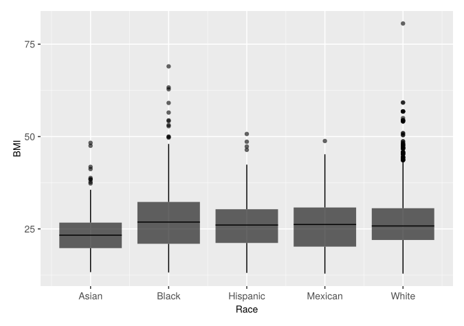

```julia
@chain nh begin
    @drop_missing(BMI)
    @filter(!ismissing(Diabetes) && Race in ["Asian", "Black", "White", "Hispanic", "Mexican"])
    ggplot(@aes(x = Race, y = BMI))
        geom_boxplot(show_notch=true)
end
```

## boxplot

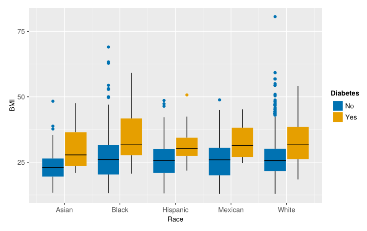

```julia
@chain nh begin
    @drop_missing(BMI)
    @filter(!ismissing(Diabetes) && Race in ["Asian", "Black", "White", "Hispanic", "Mexican"])
    ggplot(@aes(x = Race, y = BMI, color = Diabetes, dodge = Diabetes))
        geom_boxplot()
end
```

## Post-hoc

```julia
using MultipleTesting
```

# simple linear regression

## Model

$$BMI = \beta_0 + \beta_1 Age$$

[figure not shown]

## Assumptions

- Non-linearity
- Heteroscedasticity
- Outlier values
- Normality of residuals

## Non-linearity

[figure not shown]

## Heteroscedasticity

[figure not shown]

## Normality of residuals

[figure not shown]

## plot

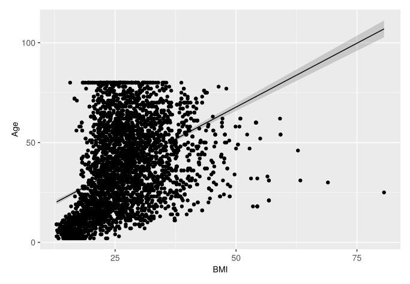

```julia
@chain nh begin
    @drop_missing(BMI)
    ggplot(@aes(x = BMI, y = Age))
        geom_point()
        geom_smooth(method = "lm")
end
```

## Fitting

```julia
nh_clean = @chain nh begin
    @drop_missing(BMI)
    @drop_missing(Age)
end
model_reg = lm(@formula(BMI ~ Age), nh_clean)
model_reg
```

```
StatsModels.TableRegressionModel{LinearModel{GLM.LmResp{Vector{Float64}}, GLM.DensePredChol{Float64, LinearAlgebra.CholeskyPivoted{Float64, Matrix{Float64}, Vector{Int64}}}}, Matrix{Float64}}

BMI ~ 1 + Age

Coefficients:
──────────────────────────────────────────────────────────────────────────
                 Coef.  Std. Error       t  Pr(>|t|)  Lower 95%  Upper 95%
──────────────────────────────────────────────────────────────────────────
(Intercept)  21.1896      0.187625  112.94    <1e-99  20.8218    21.5575
Age           0.139813    0.004307   32.46    <1e-99   0.131369   0.148256
──────────────────────────────────────────────────────────────────────────
```

## Model Diagnostics

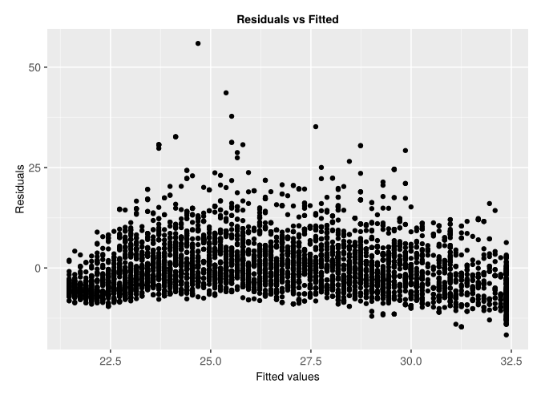

```julia
# Model diagnostics can be visualized by plotting residuals
diag = DataFrame(:res => residuals(model_reg), :fitted => predict(model_reg))

@chain diag begin
    ggplot(@aes(x = fitted, y = res))
        geom_point()
        labs(title = "Residuals vs Fitted", x = "Fitted values", y = "Residuals")
end
```

## References

- https://sparkbyexamples.com/r-programming/select-rows-in-r/
- https://4va.github.io/biodatasci/
- https://bioconnector.github.io/